# Tugas-Pertemuan-4

Nama: Aliyah Nadhratunnaim

NIM: G1401231087

# White Noise

Pembangkitan data berpola AR, MA, ARMA, dan banyak proses deret waktu lainnya diawali pembangkitan white noise.

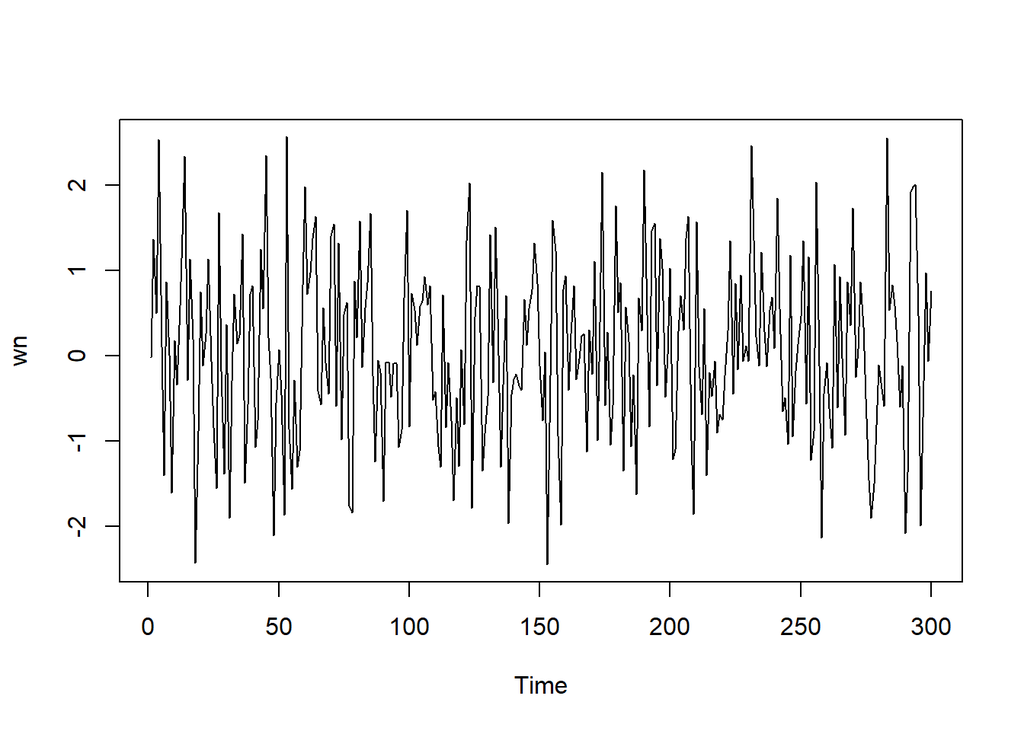

```r
set.seed(1087)
wn <- rnorm(300)
ts.plot(wn)
```

# Proses MA(2)

## Pembangkitan Proses MA(2)

Dibangkitkan proses MA(2) dengan $θ_1=0.4$ dan $θ_2=0.6$ sebanyak 300 observasi.

```r
set.seed(1087)
ma <- wn[1:2]
```

### Pembangkitan Manual MA(2)

```r
for(i in 3:300){
   ma[i] <- wn[i] + 0.4 * wn[i - 1] + 0.6*wn[i-2]
}
ma
```

```
##   [1] -0.025028561  1.367036506  1.031559475  3.556282623  1.418235404
##   [6]  0.155190336  0.358484412 -0.494882785 -1.096933060 -0.464250640
##  [11] -1.242916029  0.556143801  1.446668424  3.256027046  1.500901247
##  [16]  2.415526333  0.475461859 -1.674254343 -1.739636866 -1.061049584
##  [21] -0.352450632  0.661933149  1.163169955  0.546107275 -0.188309534
##  [26] -1.935673480  0.542816374 -0.449164946 -0.455398551 -0.301215575
##  [31] -2.595242767 -0.840536494 -0.539721051  0.253391680  0.727806402
##  [36]  1.606868234 -0.781892823 -0.314140197 -0.406952402  0.765206725
##  [41] -0.316111343 -0.698614978  0.294821391  0.595308796  3.312030000
##  [46]  1.477618509  1.229930264 -2.085604800 -1.551689191 -1.420234066
##  [51] -0.766805639 -2.017424733  1.540386176 -0.953689908 -0.373001109
##  [56] -1.427459316 -2.366358405 -1.818454208 -0.405105811  1.640067873
##  [61]  2.014400014  2.452588240  2.197392714  2.763758055  1.059480089
##  [66]  0.237409499  0.075829445 -0.207547534 -0.152818569  1.167901908
##  [71]  1.827766334  0.862932554  2.003116295 -0.810973565  0.873327954
```

[output cut: 45 more lines]

### Pembangkitan MA(2) dengan arima.sim

```r
set.seed(1087)
ma2 <- arima.sim(list(order = c(0,0,2), ma = c(0.4, 0.6)), n = 300)
ma2
```

```
## Time Series:
## Start = 1
## End = 300
## Frequency = 1
##   [1]  1.031559475  3.556282623  1.418235404  0.155190336  0.358484412
##   [6] -0.494882785 -1.096933060 -0.464250640 -1.242916029  0.556143801
##  [11]  1.446668424  3.256027046  1.500901247  2.415526333  0.475461859
##  [16] -1.674254343 -1.739636866 -1.061049584 -0.352450632  0.661933149
##  [21]  1.163169955  0.546107275 -0.188309534 -1.935673480  0.542816374
##  [26] -0.449164946 -0.455398551 -0.301215575 -2.595242767 -0.840536494
##  [31] -0.539721051  0.253391680  0.727806402  1.606868234 -0.781892823
##  [36] -0.314140197 -0.406952402  0.765206725 -0.316111343 -0.698614978
##  [41]  0.294821391  0.595308796  3.312030000  1.477618509  1.229930264
##  [46] -2.085604800 -1.551689191 -1.420234066 -0.766805639 -2.017424733
##  [51]  1.540386176 -0.953689908 -0.373001109 -1.427459316 -2.366358405
```

[output cut: 49 more lines]

## Karakteristik MA(2)

Untuk melihat karakteristik dari MA(2), digunakan data dari pembangkitan MA(2) secara manual.

### Plot Time Series

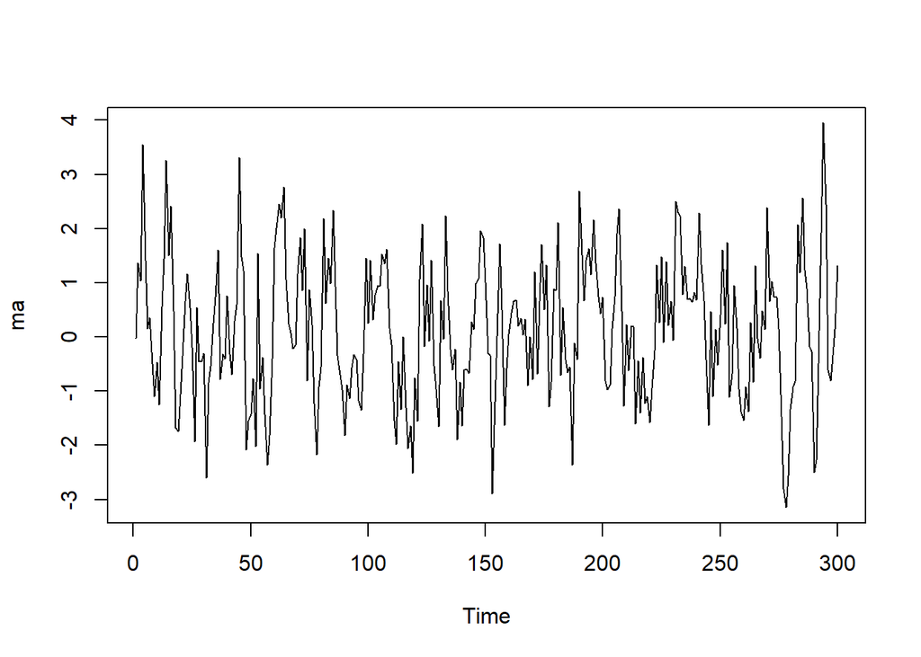

```r
ts.plot(ma)
```

Berdasarkan plot time series, terlihat bahwa data MA(2) yang dibangkitkan stasioner dalam rataan.

### Plot ACF

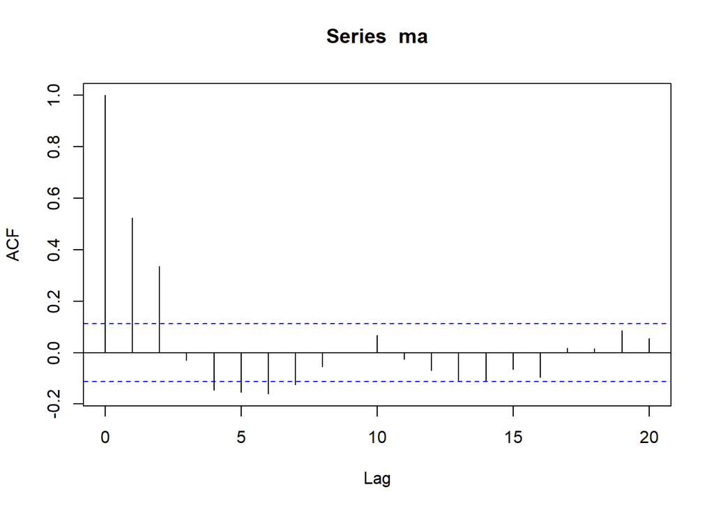

```r
acf(ma,lag.max = 20)
```

Berdasarkan plot ACF tersebut, terlihat bahwa plot ACF cuts off di lag kedua.

### Plot PACF

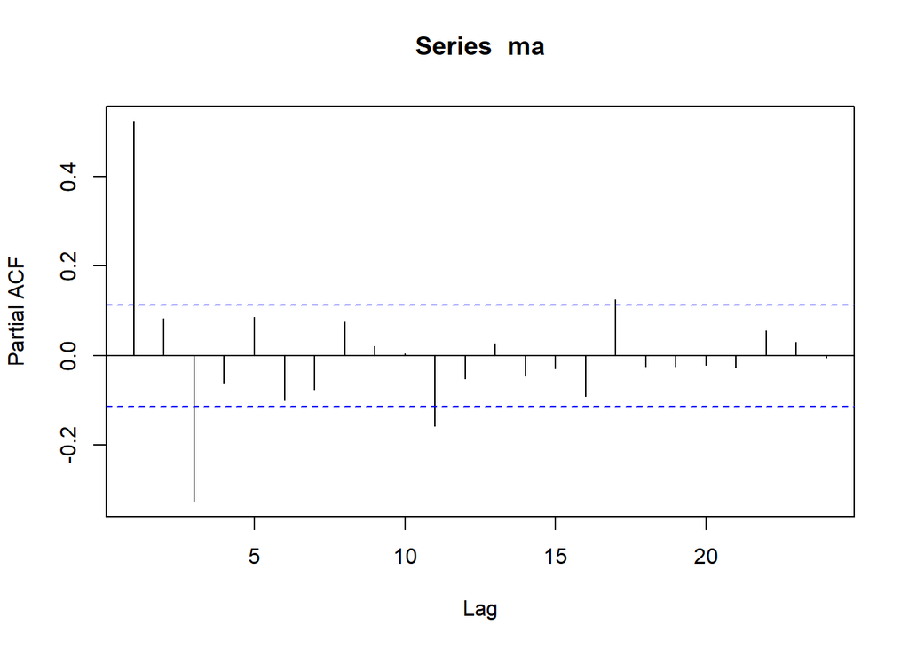

```r
pacf(ma)
```

Berdasarkan plot PACF tersebut, terlihat bahwa plot PACF cenderung *tails off* dan membentuk gelombang sinus.

### Plot EACF

```r
TSA::eacf(ma)
```

```
## AR/MA
##   0 1 2 3 4 5 6 7 8 9 10 11 12 13
## 0 x x o x x x x o o o o  o  o  o
## 1 x x o o o o o o o o o  o  o  o
## 2 x x x o o o o o o o o  o  o  o
## 3 x x x x o o o o o o o  o  o  o
## 4 x o x x o x o o o o o  o  o  o
## 5 x o x o o o o o o o o  o  o  o
## 6 x x x o o o x o o o o  o  o  o
## 7 x x x o o o x o x o o  o  o  o
```

Berdasarkan hasil EACF, pola segitiga muncul di (1,2) sehingga mengarah pada ARMA(1,2). Namun karena pada MA(2) juga terlihat cut-off yang jelas dan model ini lebih sederhana, maka MA(2) juga merupakan model yang sesuai.

## Scatterplot Antar Lag

### Korelasi antara Yt dengan Yt-1

```r
#Yt
yt_ma <- ma[-1]
yt_ma
```

```
##   [1]  1.367036506  1.031559475  3.556282623  1.418235404  0.155190336
##   [6]  0.358484412 -0.494882785 -1.096933060 -0.464250640 -1.242916029
##  [11]  0.556143801  1.446668424  3.256027046  1.500901247  2.415526333
##  [16]  0.475461859 -1.674254343 -1.739636866 -1.061049584 -0.352450632
##  [21]  0.661933149  1.163169955  0.546107275 -0.188309534 -1.935673480
##  [26]  0.542816374 -0.449164946 -0.455398551 -0.301215575 -2.595242767
##  [31] -0.840536494 -0.539721051  0.253391680  0.727806402  1.606868234
##  [36] -0.781892823 -0.314140197 -0.406952402  0.765206725 -0.316111343
##  [41] -0.698614978  0.294821391  0.595308796  3.312030000  1.477618509
##  [46]  1.229930264 -2.085604800 -1.551689191 -1.420234066 -0.766805639
##  [51] -2.017424733  1.540386176 -0.953689908 -0.373001109 -1.427459316
##  [56] -2.366358405 -1.818454208 -0.405105811  1.640067873  2.014400014
##  [61]  2.452588240  2.197392714  2.763758055  1.059480089  0.237409499
##  [66]  0.075829445 -0.207547534 -0.152818569  1.167901908  1.827766334
##  [71]  0.862932554  2.003116295 -0.810973565  0.873327954  0.225074573
```

[output cut: 45 more lines]

```r
#Yt-1
yt_1_ma <- ma[-300]
yt_1_ma
```

```
##   [1] -0.025028561  1.367036506  1.031559475  3.556282623  1.418235404
##   [6]  0.155190336  0.358484412 -0.494882785 -1.096933060 -0.464250640
##  [11] -1.242916029  0.556143801  1.446668424  3.256027046  1.500901247
##  [16]  2.415526333  0.475461859 -1.674254343 -1.739636866 -1.061049584
##  [21] -0.352450632  0.661933149  1.163169955  0.546107275 -0.188309534
##  [26] -1.935673480  0.542816374 -0.449164946 -0.455398551 -0.301215575
##  [31] -2.595242767 -0.840536494 -0.539721051  0.253391680  0.727806402
##  [36]  1.606868234 -0.781892823 -0.314140197 -0.406952402  0.765206725
##  [41] -0.316111343 -0.698614978  0.294821391  0.595308796  3.312030000
##  [46]  1.477618509  1.229930264 -2.085604800 -1.551689191 -1.420234066
##  [51] -0.766805639 -2.017424733  1.540386176 -0.953689908 -0.373001109
##  [56] -1.427459316 -2.366358405 -1.818454208 -0.405105811  1.640067873
##  [61]  2.014400014  2.452588240  2.197392714  2.763758055  1.059480089
##  [66]  0.237409499  0.075829445 -0.207547534 -0.152818569  1.167901908
##  [71]  1.827766334  0.862932554  2.003116295 -0.810973565  0.873327954
```

[output cut: 45 more lines]

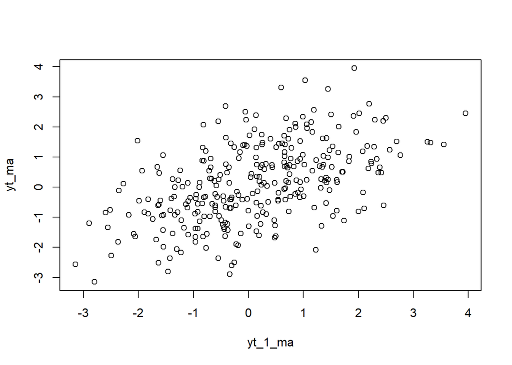

```r
plot(y=yt_ma,x=yt_1_ma)
```

```r
cor(yt_ma,yt_1_ma)
```

```
## [1] 0.5243312
```

Berdasarkan scatterplot tersebut, terlihat bahwa terdapat hubungan positif antara $Y_t$ dengan $Y_{t-1}$. Hal ini sesuai dengan teori yang ada:

Korelasi antara $Y_t$ dengan $Y_{t-1}$ dari hasil simulasi mendekati perhitungan teoritis yaitu:

$$\rho_1 = \frac{\gamma_1}{\gamma_0} = \frac{\theta_1 + \theta_1
\theta_2}{1 + \theta_1^2 + \theta_2^2} =
\frac{0.4+(0.4)(0.6)}{1+0.4^2+0.6^2}=0.421$$

### Korelasi antara Yt dengan Yt-2

```r
#Yt
yt_ma2 <- ma[-c(1,2)]
yt_ma2
```

```
##   [1]  1.031559475  3.556282623  1.418235404  0.155190336  0.358484412
##   [6] -0.494882785 -1.096933060 -0.464250640 -1.242916029  0.556143801
##  [11]  1.446668424  3.256027046  1.500901247  2.415526333  0.475461859
##  [16] -1.674254343 -1.739636866 -1.061049584 -0.352450632  0.661933149
##  [21]  1.163169955  0.546107275 -0.188309534 -1.935673480  0.542816374
##  [26] -0.449164946 -0.455398551 -0.301215575 -2.595242767 -0.840536494
##  [31] -0.539721051  0.253391680  0.727806402  1.606868234 -0.781892823
##  [36] -0.314140197 -0.406952402  0.765206725 -0.316111343 -0.698614978
##  [41]  0.294821391  0.595308796  3.312030000  1.477618509  1.229930264
##  [46] -2.085604800 -1.551689191 -1.420234066 -0.766805639 -2.017424733
##  [51]  1.540386176 -0.953689908 -0.373001109 -1.427459316 -2.366358405
##  [56] -1.818454208 -0.405105811  1.640067873  2.014400014  2.452588240
##  [61]  2.197392714  2.763758055  1.059480089  0.237409499  0.075829445
##  [66] -0.207547534 -0.152818569  1.167901908  1.827766334  0.862932554
##  [71]  2.003116295 -0.810973565  0.873327954  0.225074573 -1.223144108
```

[output cut: 45 more lines]

```r
#Yt-2
yt_2_ma <- ma[-c(299,300)]
yt_2_ma
```

```
##   [1] -0.025028561  1.367036506  1.031559475  3.556282623  1.418235404
##   [6]  0.155190336  0.358484412 -0.494882785 -1.096933060 -0.464250640
##  [11] -1.242916029  0.556143801  1.446668424  3.256027046  1.500901247
##  [16]  2.415526333  0.475461859 -1.674254343 -1.739636866 -1.061049584
##  [21] -0.352450632  0.661933149  1.163169955  0.546107275 -0.188309534
##  [26] -1.935673480  0.542816374 -0.449164946 -0.455398551 -0.301215575
##  [31] -2.595242767 -0.840536494 -0.539721051  0.253391680  0.727806402
##  [36]  1.606868234 -0.781892823 -0.314140197 -0.406952402  0.765206725
##  [41] -0.316111343 -0.698614978  0.294821391  0.595308796  3.312030000
##  [46]  1.477618509  1.229930264 -2.085604800 -1.551689191 -1.420234066
##  [51] -0.766805639 -2.017424733  1.540386176 -0.953689908 -0.373001109
##  [56] -1.427459316 -2.366358405 -1.818454208 -0.405105811  1.640067873
##  [61]  2.014400014  2.452588240  2.197392714  2.763758055  1.059480089
##  [66]  0.237409499  0.075829445 -0.207547534 -0.152818569  1.167901908
##  [71]  1.827766334  0.862932554  2.003116295 -0.810973565  0.873327954
```

[output cut: 45 more lines]

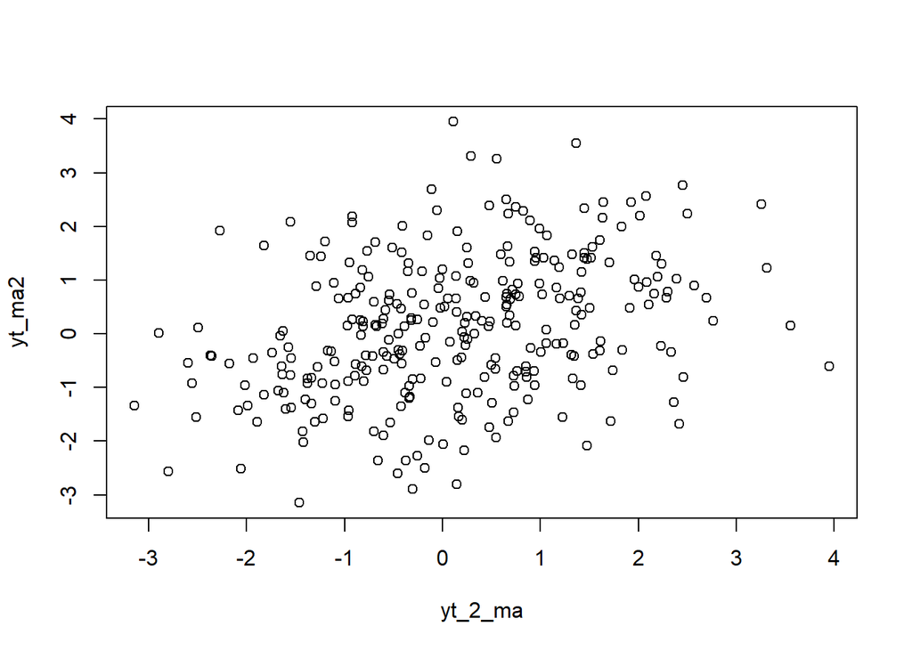

```r
plot(y=yt_ma2,x=yt_2_ma)
```

```r
cor(yt_ma2,yt_2_ma)
```

```
## [1] 0.3357633
```

Berdasarkan scatterplot tersebut, terlihat bahwa terdapat hubungan positif antara $Y_t$ dengan $Y_{t-2}$. Hal ini sesuai dengan teori yang ada:

Korelasi antara $Y_t$ dengan $Y_{t-2}$ dari hasil simulasi mendekati perhitungan teoritis yaitu:

$$\rho_2 = \frac{\gamma_2}{\gamma_0} =
\frac{\theta_2}{1 + \theta_1^2 + \theta_2^2} =
\frac{0.6}{1+0.4^2+0.6^2}=0.395$$

### Korelasi antara Yt dengan Yt-3

```r
#Yt
yt_ma3 <- ma[-c(1,2,3)]
yt_ma3
```

```
##   [1]  3.556282623  1.418235404  0.155190336  0.358484412 -0.494882785
##   [6] -1.096933060 -0.464250640 -1.242916029  0.556143801  1.446668424
##  [11]  3.256027046  1.500901247  2.415526333  0.475461859 -1.674254343
##  [16] -1.739636866 -1.061049584 -0.352450632  0.661933149  1.163169955
##  [21]  0.546107275 -0.188309534 -1.935673480  0.542816374 -0.449164946
##  [26] -0.455398551 -0.301215575 -2.595242767 -0.840536494 -0.539721051
##  [31]  0.253391680  0.727806402  1.606868234 -0.781892823 -0.314140197
##  [36] -0.406952402  0.765206725 -0.316111343 -0.698614978  0.294821391
##  [41]  0.595308796  3.312030000  1.477618509  1.229930264 -2.085604800
##  [46] -1.551689191 -1.420234066 -0.766805639 -2.017424733  1.540386176
##  [51] -0.953689908 -0.373001109 -1.427459316 -2.366358405 -1.818454208
##  [56] -0.405105811  1.640067873  2.014400014  2.452588240  2.197392714
##  [61]  2.763758055  1.059480089  0.237409499  0.075829445 -0.207547534
##  [66] -0.152818569  1.167901908  1.827766334  0.862932554  2.003116295
##  [71] -0.810973565  0.873327954  0.225074573 -1.223144108 -2.173519054
```

[output cut: 45 more lines]

```r
#Yt-3
yt_3_ma <- ma[-c(298, 299,300)]
yt_3_ma
```

```
##   [1] -0.025028561  1.367036506  1.031559475  3.556282623  1.418235404
##   [6]  0.155190336  0.358484412 -0.494882785 -1.096933060 -0.464250640
##  [11] -1.242916029  0.556143801  1.446668424  3.256027046  1.500901247
##  [16]  2.415526333  0.475461859 -1.674254343 -1.739636866 -1.061049584
##  [21] -0.352450632  0.661933149  1.163169955  0.546107275 -0.188309534
##  [26] -1.935673480  0.542816374 -0.449164946 -0.455398551 -0.301215575
##  [31] -2.595242767 -0.840536494 -0.539721051  0.253391680  0.727806402
##  [36]  1.606868234 -0.781892823 -0.314140197 -0.406952402  0.765206725
##  [41] -0.316111343 -0.698614978  0.294821391  0.595308796  3.312030000
##  [46]  1.477618509  1.229930264 -2.085604800 -1.551689191 -1.420234066
##  [51] -0.766805639 -2.017424733  1.540386176 -0.953689908 -0.373001109
##  [56] -1.427459316 -2.366358405 -1.818454208 -0.405105811  1.640067873
##  [61]  2.014400014  2.452588240  2.197392714  2.763758055  1.059480089
##  [66]  0.237409499  0.075829445 -0.207547534 -0.152818569  1.167901908
##  [71]  1.827766334  0.862932554  2.003116295 -0.810973565  0.873327954
```

[output cut: 45 more lines]

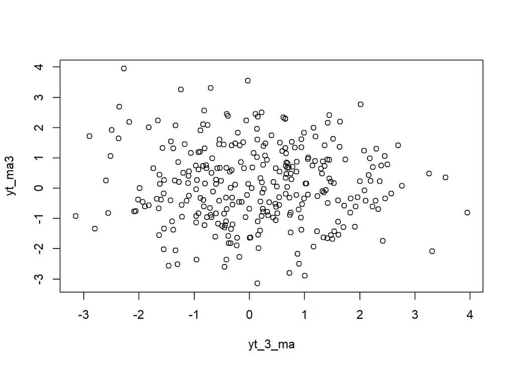

```r
plot(y=yt_ma3,x=yt_3_ma)
```

```r
cor(yt_ma3,yt_3_ma)
```

```
## [1] -0.03048188
```

Berdasarkan scatterplot tersebut, terlihat bahwa cenderung tidak terdapat hubungan antara $Y_t$ dengan $Y_{t−3}$. Korelasi antara $Y_t$ dengan $Y_{t−3}$ hasil simulasi mendekati teori yang ada yaitu 0.

# Proses AR(2)

## Pembangkitan Proses AR(2)

Dibangkitkan proses AR(2) dengan $ϕ_1=0.5$ dan $ϕ_2=0.2$ sebanyak 300 observasi.

```r
set.seed(1087)
ar <- wn[1:2]
```

### Pembangkitan Manual AR(2)

```r
for (i in 3:300) {
  ar[i] <- wn[i] + 0.5 * ar[i-1] + 0.2 * ar[i-2]
}
ar
```

```
##   [1] -0.025028561  1.367036506  1.178274550  3.398700492  2.038920988
##   [6]  0.291131046  1.412712452  0.770796286 -0.947095606 -0.141353001
##  [11] -0.605204125  0.256493213  1.425992957  3.100387772  1.550584358
##  [16]  2.523163723  1.766927868 -1.040925712 -1.052242673  0.016123528
##  [21] -0.323910171  0.101554125  1.117965222  0.516441930 -0.360537038
##  [26] -1.638002291  0.781527313 -0.118442800 -1.289253608 -0.306032272
##  [31] -2.319220259 -1.515381573 -0.498417853 -0.411401362 -0.067801593
##  [36]  1.311123774 -0.853362787 -0.736833999  0.180127599  0.763643278
##  [41] -0.658172989 -0.937132525  0.644542494  0.688721008  2.816902484
##  [46]  1.754034800  1.181012330 -1.165241063 -0.899854241 -0.617902417
##  [51] -0.949695157 -2.470587305  1.140481050 -0.780556791 -1.731939592
##  [56] -1.307629594 -2.310487300 -2.539780879 -0.901718436  1.022951480
##  [61]  1.054663639  1.706037597  2.437579096  3.189834806  1.665801674
##  [66]  0.897027274  1.337018555  0.762533679  0.196797653  1.650785261
##  [71]  2.403690354  0.939431687  2.267235510  0.339360214  1.099243757
```

[output cut: 45 more lines]

### Pembangkitan AR(2) dengan arima.sim

```r
ar1 <- arima.sim(list(order=c(2,0,0), ar=c(0.5, 0.2)), n=300)
ar1
```

```
## Time Series:
## Start = 1
## End = 300
## Frequency = 1
##   [1] -1.638016115  0.781516774 -0.118450834 -1.289259733 -0.306036941
##   [6] -2.319223819 -1.515384287 -0.498419922 -0.411402939 -0.067802795
##  [11]  1.311122857 -0.853363485 -0.736834531  0.180127193  0.763642968
##  [16] -0.658173225 -0.937132704  0.644542357  0.688720903  2.816902405
##  [21]  1.754034740  1.181012283 -1.165241098 -0.899854268 -0.617902437
##  [26] -0.949695172 -2.470587317  1.140481041 -0.780556798 -1.731939598
##  [31] -1.307629598 -2.310487303 -2.539780881 -0.901718438  1.022951479
##  [36]  1.054663638  1.706037596  2.437579096  3.189834806  1.665801674
##  [41]  0.897027273  1.337018555  0.762533679  0.196797653  1.650785261
##  [46]  2.403690354  0.939431687  2.267235510  0.339360214  1.099243757
##  [51]  1.241408202 -0.917826897 -2.055147531 -0.339643283 -0.373078650
```

[output cut: 49 more lines]

## Karakteristik AR(2)

### Plot Time Series

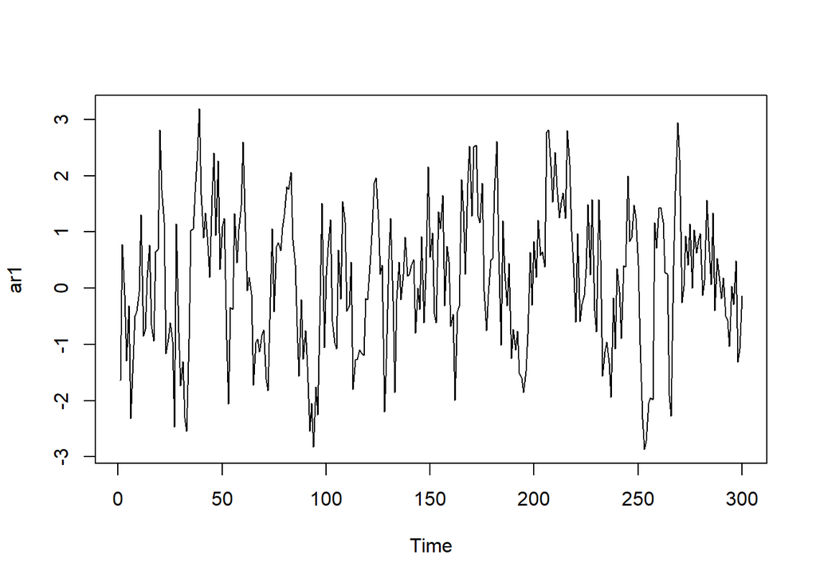

```r
ts.plot(ar1)
```

Berdasarkan plot time series tersebut terlihat bahwa data cenderung stasioner pada rataan.

### Plot ACF

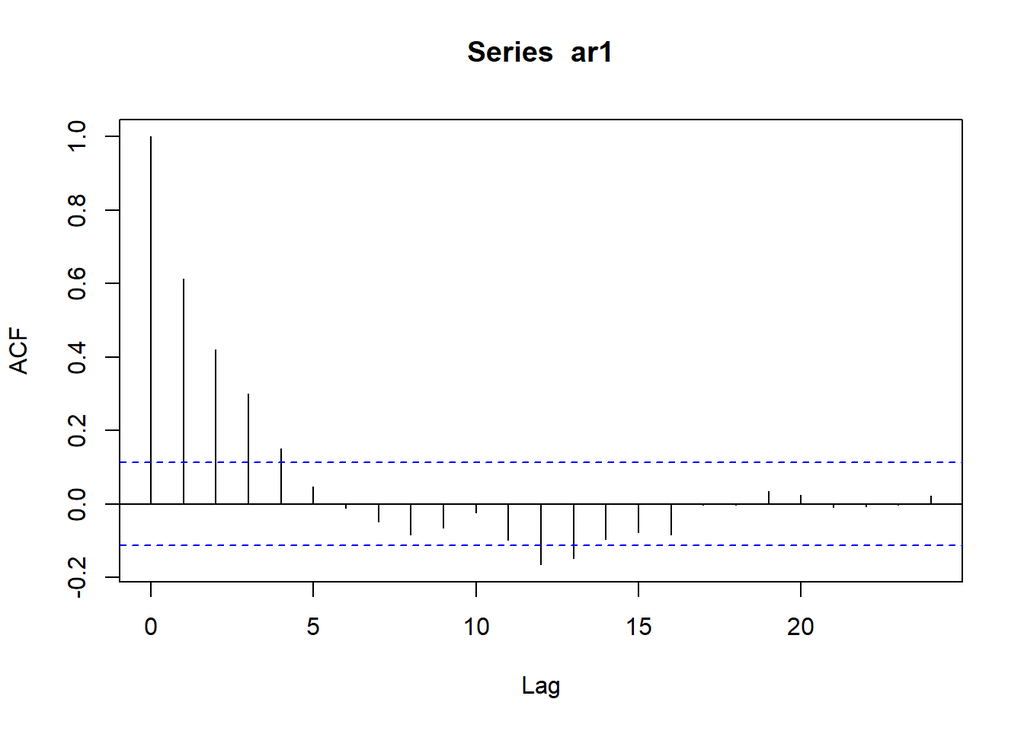

```r
acf(ar1)
```

Berdasarkan plot ACF tersebut terlihat bahwa plot ACF cenderung *tails off* dan cenderung membentuk pola grafik sinus.

### Plot PACF

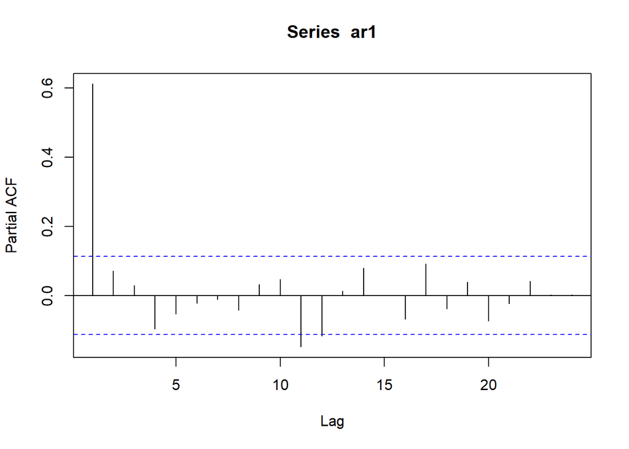

```r
pacf(ar1)
```

### Plot EACF

```r
TSA::eacf(ar1)
```

```
## AR/MA
##   0 1 2 3 4 5 6 7 8 9 10 11 12 13
## 0 x x x x o o o o o o o  x  x  o
## 1 o o x o o o o o o o o  o  o  o
## 2 x o x o o o o o o o o  o  o  o
## 3 x x o o o o o o o o o  o  o  o
## 4 x x o o o o o o o o o  o  o  o
## 5 x x o o o o o o o o o  o  o  o
## 6 x o x o o o o o o o o  o  o  o
## 7 x x x o o o o o o o o  o  o  o
```

## Scatterplot Antar Lag

### Korelasi antara Yt dengan Yt-1

```r
#Yt
yt_ar <- ar1[-1]
yt_ar
```

```
##   [1]  0.781516774 -0.118450834 -1.289259733 -0.306036941 -2.319223819
##   [6] -1.515384287 -0.498419922 -0.411402939 -0.067802795  1.311122857
##  [11] -0.853363485 -0.736834531  0.180127193  0.763642968 -0.658173225
##  [16] -0.937132704  0.644542357  0.688720903  2.816902405  1.754034740
##  [21]  1.181012283 -1.165241098 -0.899854268 -0.617902437 -0.949695172
##  [26] -2.470587317  1.140481041 -0.780556798 -1.731939598 -1.307629598
##  [31] -2.310487303 -2.539780881 -0.901718438  1.022951479  1.054663638
##  [36]  1.706037596  2.437579096  3.189834806  1.665801674  0.897027273
##  [41]  1.337018555  0.762533679  0.196797653  1.650785261  2.403690354
##  [46]  0.939431687  2.267235510  0.339360214  1.099243757  1.241408202
##  [51] -0.917826897 -2.055147531 -0.339643283 -0.373078650  1.324887222
##  [56]  0.450553367  1.045642242  1.464655924  2.604642386  1.357819614
##  [61] -0.045165248  0.192800238 -0.108695652 -1.724221601 -0.969986361
##  [66] -0.903615311 -1.134458285 -0.838734944 -0.737537270 -1.612900315
##  [71] -1.822559662 -0.555666502  1.059365966 -0.419088976  0.733440504
```

[output cut: 45 more lines]

```r
#Yt-1
yt_1_ar <- ar1[-300]
yt_1_ar
```

```
##   [1] -1.638016115  0.781516774 -0.118450834 -1.289259733 -0.306036941
##   [6] -2.319223819 -1.515384287 -0.498419922 -0.411402939 -0.067802795
##  [11]  1.311122857 -0.853363485 -0.736834531  0.180127193  0.763642968
##  [16] -0.658173225 -0.937132704  0.644542357  0.688720903  2.816902405
##  [21]  1.754034740  1.181012283 -1.165241098 -0.899854268 -0.617902437
##  [26] -0.949695172 -2.470587317  1.140481041 -0.780556798 -1.731939598
##  [31] -1.307629598 -2.310487303 -2.539780881 -0.901718438  1.022951479
##  [36]  1.054663638  1.706037596  2.437579096  3.189834806  1.665801674
##  [41]  0.897027273  1.337018555  0.762533679  0.196797653  1.650785261
##  [46]  2.403690354  0.939431687  2.267235510  0.339360214  1.099243757
##  [51]  1.241408202 -0.917826897 -2.055147531 -0.339643283 -0.373078650
##  [56]  1.324887222  0.450553367  1.045642242  1.464655924  2.604642386
##  [61]  1.357819614 -0.045165248  0.192800238 -0.108695652 -1.724221601
##  [66] -0.969986361 -0.903615311 -1.134458285 -0.838734944 -0.737537270
##  [71] -1.612900315 -1.822559662 -0.555666502  1.059365966 -0.419088976
```

[output cut: 45 more lines]

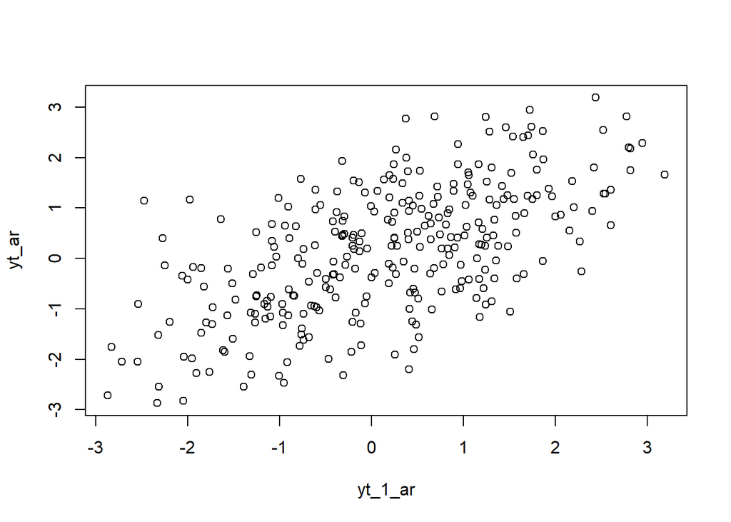

```r
plot(y=yt_ar,x=yt_1_ar)
```

Berdasarkan scatterplot tersebut, terlihat bahwa terdapat hubungan positif antara $Y_t$ dengan $Y_{t-1}$. Hal ini sesuai dengan teori yang ada

```r
cor(yt_ar,yt_1_ar)
```

```
## [1] 0.6142265
```

Korelasi antara $Y_t$ dengan $Y_{t-1}$ dari hasil simulasi mendekati perhitungan teoritis yaitu:

$$\rho_1 = \frac{\phi_1}{1 - \phi_2}=\frac{0.5}{1-0.2}=0.625$$

### Korelasi antara Yt dengan Yt-2

```r
#Yt
yt_ar2 <- ar1[-c(1,2)]
yt_ar2
```

```
##   [1] -0.118450834 -1.289259733 -0.306036941 -2.319223819 -1.515384287
##   [6] -0.498419922 -0.411402939 -0.067802795  1.311122857 -0.853363485
##  [11] -0.736834531  0.180127193  0.763642968 -0.658173225 -0.937132704
##  [16]  0.644542357  0.688720903  2.816902405  1.754034740  1.181012283
##  [21] -1.165241098 -0.899854268 -0.617902437 -0.949695172 -2.470587317
##  [26]  1.140481041 -0.780556798 -1.731939598 -1.307629598 -2.310487303
##  [31] -2.539780881 -0.901718438  1.022951479  1.054663638  1.706037596
##  [36]  2.437579096  3.189834806  1.665801674  0.897027273  1.337018555
##  [41]  0.762533679  0.196797653  1.650785261  2.403690354  0.939431687
##  [46]  2.267235510  0.339360214  1.099243757  1.241408202 -0.917826897
##  [51] -2.055147531 -0.339643283 -0.373078650  1.324887222  0.450553367
##  [56]  1.045642242  1.464655924  2.604642386  1.357819614 -0.045165248
##  [61]  0.192800238 -0.108695652 -1.724221601 -0.969986361 -0.903615311
##  [66] -1.134458285 -0.838734944 -0.737537270 -1.612900315 -1.822559662
##  [71] -0.555666502  1.059365966 -0.419088976  0.733440504  0.814209972
```

[output cut: 45 more lines]

```r
#Yt-2
yt_2_ar <- ar1[-c(299,300)]
yt_2_ar
```

```
##   [1] -1.638016115  0.781516774 -0.118450834 -1.289259733 -0.306036941
##   [6] -2.319223819 -1.515384287 -0.498419922 -0.411402939 -0.067802795
##  [11]  1.311122857 -0.853363485 -0.736834531  0.180127193  0.763642968
##  [16] -0.658173225 -0.937132704  0.644542357  0.688720903  2.816902405
##  [21]  1.754034740  1.181012283 -1.165241098 -0.899854268 -0.617902437
##  [26] -0.949695172 -2.470587317  1.140481041 -0.780556798 -1.731939598
##  [31] -1.307629598 -2.310487303 -2.539780881 -0.901718438  1.022951479
##  [36]  1.054663638  1.706037596  2.437579096  3.189834806  1.665801674
##  [41]  0.897027273  1.337018555  0.762533679  0.196797653  1.650785261
##  [46]  2.403690354  0.939431687  2.267235510  0.339360214  1.099243757
##  [51]  1.241408202 -0.917826897 -2.055147531 -0.339643283 -0.373078650
##  [56]  1.324887222  0.450553367  1.045642242  1.464655924  2.604642386
##  [61]  1.357819614 -0.045165248  0.192800238 -0.108695652 -1.724221601
##  [66] -0.969986361 -0.903615311 -1.134458285 -0.838734944 -0.737537270
##  [71] -1.612900315 -1.822559662 -0.555666502  1.059365966 -0.419088976
```

[output cut: 45 more lines]

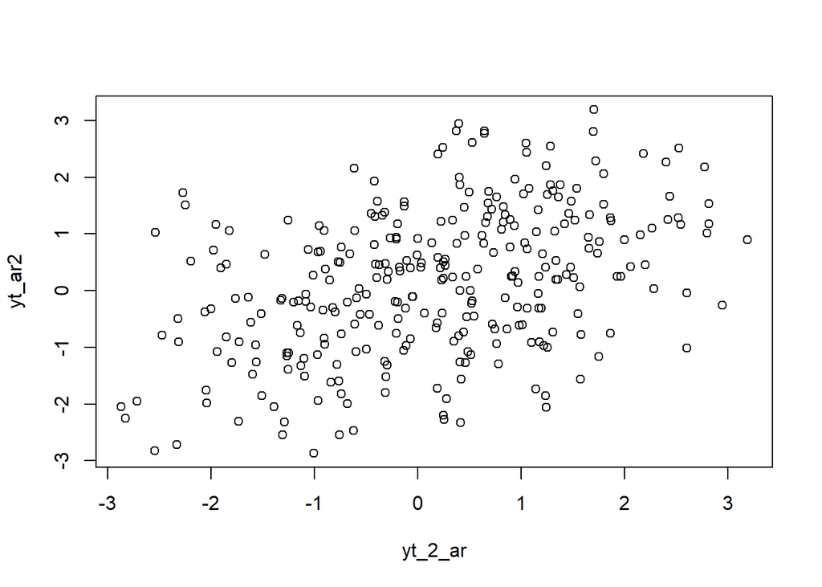

```r
plot(y=yt_ar2,x=yt_2_ar)
```

Berdasarkan scatterplot tersebut, terlihat bahwa terdapat hubungan positif antara $Y_t$ dengan $Y_{t-2}$. Hal ini sesuai dengan teori yang ada

```r
cor(yt_ar2,yt_2_ar)
```

```
## [1] 0.4215845
```

Korelasi antara $Y_t$ dengan $Y_{t-2}$ dari hasil simulasi mendekati perhitungan teoritis yaitu:

$$\rho_2 = \frac{\phi_1 \rho_1 + \phi_2}{1}
= \frac{\phi_1^2}{1 - \phi_2} +
\phi_2=\frac{0.5^2}{1-0.2}+0.2=0.5125$$

### Korelasi antara Yt dengan Yt-3

```r
#Yt
yt_ar3 <- ar1[-c(1,2,3)]
yt_ar3
```

```
##   [1] -1.289259733 -0.306036941 -2.319223819 -1.515384287 -0.498419922
##   [6] -0.411402939 -0.067802795  1.311122857 -0.853363485 -0.736834531
##  [11]  0.180127193  0.763642968 -0.658173225 -0.937132704  0.644542357
##  [16]  0.688720903  2.816902405  1.754034740  1.181012283 -1.165241098
##  [21] -0.899854268 -0.617902437 -0.949695172 -2.470587317  1.140481041
##  [26] -0.780556798 -1.731939598 -1.307629598 -2.310487303 -2.539780881
##  [31] -0.901718438  1.022951479  1.054663638  1.706037596  2.437579096
##  [36]  3.189834806  1.665801674  0.897027273  1.337018555  0.762533679
##  [41]  0.196797653  1.650785261  2.403690354  0.939431687  2.267235510
##  [46]  0.339360214  1.099243757  1.241408202 -0.917826897 -2.055147531
##  [51] -0.339643283 -0.373078650  1.324887222  0.450553367  1.045642242
##  [56]  1.464655924  2.604642386  1.357819614 -0.045165248  0.192800238
##  [61] -0.108695652 -1.724221601 -0.969986361 -0.903615311 -1.134458285
##  [66] -0.838734944 -0.737537270 -1.612900315 -1.822559662 -0.555666502
##  [71]  1.059365966 -0.419088976  0.733440504  0.814209972  0.674057138
```

[output cut: 45 more lines]

```r
#Yt-3
yt_3_ar <- ar1[-c(298,299,300)]
yt_3_ar
```

```
##   [1] -1.638016115  0.781516774 -0.118450834 -1.289259733 -0.306036941
##   [6] -2.319223819 -1.515384287 -0.498419922 -0.411402939 -0.067802795
##  [11]  1.311122857 -0.853363485 -0.736834531  0.180127193  0.763642968
##  [16] -0.658173225 -0.937132704  0.644542357  0.688720903  2.816902405
##  [21]  1.754034740  1.181012283 -1.165241098 -0.899854268 -0.617902437
##  [26] -0.949695172 -2.470587317  1.140481041 -0.780556798 -1.731939598
##  [31] -1.307629598 -2.310487303 -2.539780881 -0.901718438  1.022951479
##  [36]  1.054663638  1.706037596  2.437579096  3.189834806  1.665801674
##  [41]  0.897027273  1.337018555  0.762533679  0.196797653  1.650785261
##  [46]  2.403690354  0.939431687  2.267235510  0.339360214  1.099243757
##  [51]  1.241408202 -0.917826897 -2.055147531 -0.339643283 -0.373078650
##  [56]  1.324887222  0.450553367  1.045642242  1.464655924  2.604642386
##  [61]  1.357819614 -0.045165248  0.192800238 -0.108695652 -1.724221601
##  [66] -0.969986361 -0.903615311 -1.134458285 -0.838734944 -0.737537270
##  [71] -1.612900315 -1.822559662 -0.555666502  1.059365966 -0.419088976
```

[output cut: 45 more lines]

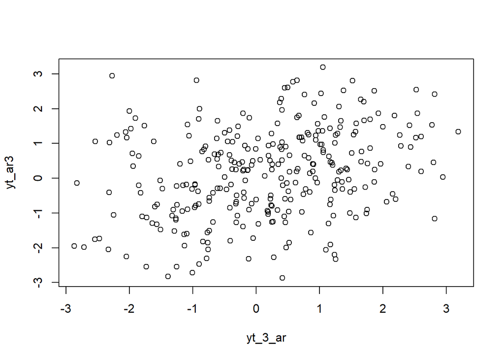

```r
plot(y=yt_ar3,x=yt_3_ar)
```

Berdasarkan scatterplot tersebut, terlihat bahwa terdapat hubungan positif antara $Y_t$ dengan $Y_{t-3}$. Hal ini sesuai dengan teori yang ada

```r
cor(yt_ar3,yt_3_ar)
```

```
## [1] 0.3022409
```

Korelasi antara $Y_t$ dengan $Y_{t-3}$ dari hasil simulasi mendekati perhitungan teoritis yaitu:

$$\rho_3 = \phi_1 \rho_2 + \phi_2 \rho_1=0.5(0.5125)+0.2(0.625)=0.38125$$

# Proses ARMA(2,2)

## Pembangkitan Proses ARMA(2,2)

### Fungsi pembangkitan ARMA (secara manual)

```r
arma.sim <- function(n, macoef, arcoef){
  manum <- length(macoef)
  arnum <- length(arcoef)
  stopifnot(manum < n & arnum < n)

  wn <- rnorm(n, sd = 0.5)
  init <- max(manum, arnum)

  arma <- wn[1:init]
  for(i in {init+1}:n){
   mastart <- i - manum
   maend <- i-1
   arstart <- i - arnum
   arend <- i-1
   arma[i] <- sum(arcoef * arma[arstart:arend]) + sum(macoef * wn[mastart:maend])  + wn[i]
   }
  return(arma)
}
```

```r
#contoh untuk ARMA(2,2)
arma22 <- arma.sim(300, c(0.4, 0.6), c(0.5,0.2))

arma22 |> arima(c(2,0,2))
```

```
##
## Call:
## arima(x = arma22, order = c(2, 0, 2))
##
## Coefficients:
##          ar1     ar2     ma1     ma2  intercept
##       0.2278  0.4976  0.5915  0.4153     0.1288
## s.e.  0.0822  0.0783  0.0823  0.0618     0.2053
##
## sigma^2 estimated as 0.2445:  log likelihood = -215.45,  aic = 442.89
```

```r
set.seed(1087)

n <- 300
phi1 <- 0.4
phi2 <- -0.6
theta1 <- 0.5
theta2 <- 0.2

wn <- rnorm(n)

y.arma <- numeric(n)
y.arma[1:2] <- wn[1:2]   # nilai awal biar gak NA

for (i in 3:n) {
  y.arma[i] <- phi1 * y.arma[i-1] +
               phi2 * y.arma[i-2] +
               theta1 * wn[i-1] +
               theta2 * wn[i-2] +
               wn[i]
}

y.arma
```

```
##   [1] -0.025028561  1.367036506  1.740106290  2.935264834  1.601988351
##   [6] -1.969244007 -1.572779488  0.706715916 -0.213702709 -1.137750438
##  [11] -0.905976528  0.770678384  2.495305683  3.698674656  1.149282094
##  [16] -0.306883496 -0.110158149 -1.965782187 -2.780848745 -0.110827352
##  [21]  1.700836831  1.096439950  0.655881648  0.159679181 -0.977040078
##  [26] -2.481391523  0.317322015  1.958271223 -0.549698217 -1.762048963
##  [31] -2.379480045 -1.070847712  1.193512753  1.563443102  0.361917584
##  [36]  0.780974120 -0.638956304 -1.758765563 -0.186176838  2.046867987
##  [41]  0.408749720 -2.199216408 -0.475784413  2.153309085  4.016314567
##  [46]  1.804971726 -1.374539242 -3.827477833 -2.364857970  0.717587503
##  [51]  1.167025906 -2.053273349  0.015954609  1.290091016 -0.978490946
##  [56] -2.407214102 -2.142801359 -1.248055372  0.793165558  3.238398790
##  [61]  2.699929097  0.869167014  0.733100975  2.283214801  1.146438171
##  [66] -1.367542364 -1.049781836  0.478135818  0.437628921  1.045037117
##  [71]  2.303940957  0.751428606  0.246490832 -0.794528020 -0.217304780
```

[output cut: 45 more lines]

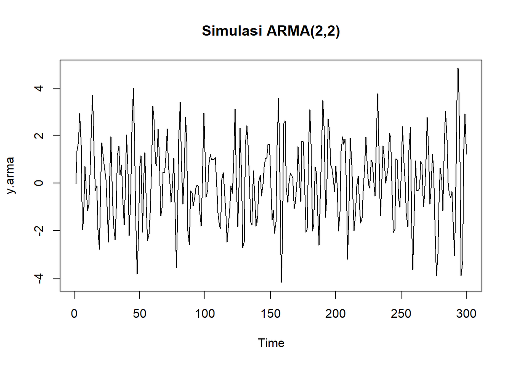

```r
ts.plot(y.arma, main="Simulasi ARMA(2,2)")
```

### Pembangkitan ARMA(2,2) dengan arima.sim

```r
arma22 <- arima.sim(
  list(order = c(2,0,2), ar = c(0.5, 0.2), ma = c(0.4, 0.6)),
  n = 300
)
arma22
```

```
## Time Series:
## Start = 1
## End = 300
## Frequency = 1
##   [1]  0.521389891  1.202186204  1.829616212  3.338987674  1.597880477
##   [6]  1.343086922 -0.893315311 -0.783861667 -2.122426266 -3.214666908
##  [11] -3.604458242 -4.085991203 -1.416574090 -1.587141776  0.836410375
##  [16] -0.698279074 -1.033891756  0.401878485  0.963779574  1.737426411
##  [21]  2.027534887  1.783057485  3.228028156  1.902817714  2.326184595
##  [26]  0.429177593 -1.265925023 -3.690439177 -3.536829619 -3.255881391
##  [31] -0.883482236 -0.236910677  0.562672469 -1.641086593  0.093760401
##  [36] -3.128878431 -1.639196015 -3.535617598 -2.078776092 -0.408698060
##  [41]  0.854523269  3.537265448  4.130777554  5.672467388  5.356942826
##  [46]  6.283429418  6.844103560  6.340822559  5.480226200  4.849967345
##  [51]  3.807529429  2.512366668  2.220531582  0.939693323  0.869860544
```

[output cut: 49 more lines]

## Karakteristik ARMA(2,2)

### Plot Time Series

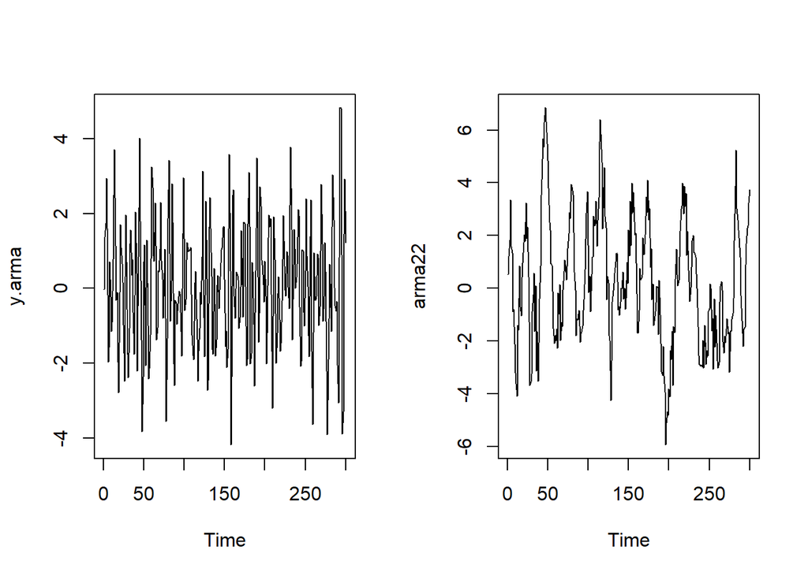

```r
par(mfrow = c(1, 2))
ts.plot(y.arma)
ts.plot(arma22)
```

Berdasarkan plot time series tersebut, terlihat bahwa model ARMA(2,2) cenderung stasioner dalam rataan

### Plot ACF

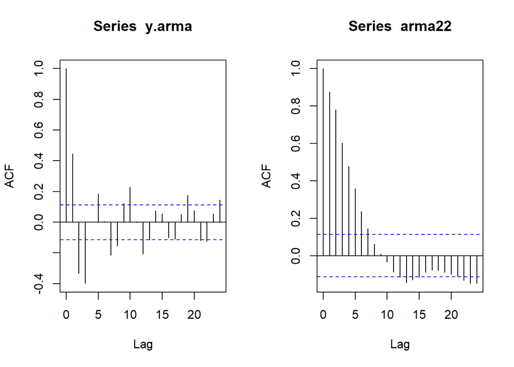

```r
par(mfrow = c(1, 2))
acf(y.arma)
acf(arma22)
```

Berdasarkan plot ACF tersebut, terlihat bahwa model ARMA(2,2) hasil simulasi memiliki plot ACF yang *tails off,* sesuai dengan teori yang ada.

### Plot PACF

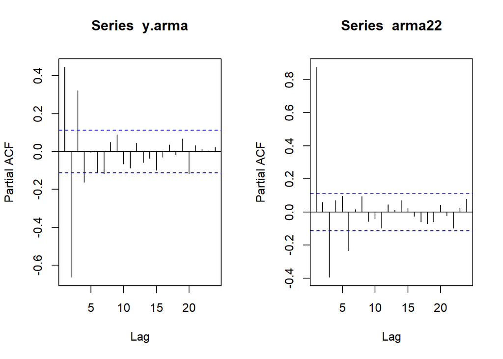

```r
par(mfrow = c(1, 2))
pacf(y.arma)
pacf(arma22)
```

Berdasarkan plot PACF tersebut, terlihat bahwa model ARMA(2,2) hasil simulasi memiliki plot PACF yang *tails off*, sesuai dengan teori

### Plot EACF

```r
TSA::eacf(y.arma)
```

```
## AR/MA
##   0 1 2 3 4 5 6 7 8 9 10 11 12 13
## 0 x x x o x o x x x x o  x  o  o
## 1 x x x o x o x x x x o  x  x  x
## 2 x o o x x x o o o o o  x  o  o
## 3 x o o o x x x o o o o  o  o  o
## 4 o x o o x x o o o o o  o  o  o
## 5 o x o x o x o o o o o  o  o  o
## 6 x x x o o o o o o o o  o  o  o
## 7 x x x o o o o o o x o  o  o  o
```

Berdasarkan hasil EACF, pola segitiga muncul di (2,1) sehingga mengarah pada ARMA(2,1).

```r
TSA::eacf(arma22)
```

```
## AR/MA
##   0 1 2 3 4 5 6 7 8 9 10 11 12 13
## 0 x x x x x x x o o o o  o  x  x
## 1 o x o o x o o o o o o  o  x  o
## 2 x x x o x o o o o o o  o  x  o
## 3 x x x x x o o o o x o  o  x  o
## 4 x x x o x o o o o x o  o  x  o
## 5 x x x o x o o o o x o  o  x  o
## 6 o x x o x o x x o x o  o  x  o
## 7 o x x o x o o x o o o  o  x  o
```

Berdasarkan hasil EACF, pola segitiga muncul di (1,2) sehingga mengarah pada ARMA(1,2).

## Scatterplot antar lag

### Korelasi antara Yt dengan Yt-1

```r
#Yt
yt_arma <- arma22[-1]
yt_arma
```

```
##   [1]  1.202186204  1.829616212  3.338987674  1.597880477  1.343086922
##   [6] -0.893315311 -0.783861667 -2.122426266 -3.214666908 -3.604458242
##  [11] -4.085991203 -1.416574090 -1.587141776  0.836410375 -0.698279074
##  [16] -1.033891756  0.401878485  0.963779574  1.737426411  2.027534887
##  [21]  1.783057485  3.228028156  1.902817714  2.326184595  0.429177593
##  [26] -1.265925023 -3.690439177 -3.536829619 -3.255881391 -0.883482236
##  [31] -0.236910677  0.562672469 -1.641086593  0.093760401 -3.128878431
##  [36] -1.639196015 -3.535617598 -2.078776092 -0.408698060  0.854523269
##  [41]  3.537265448  4.130777554  5.672467388  5.356942826  6.283429418
##  [46]  6.844103560  6.340822559  5.480226200  4.849967345  3.807529429
##  [51]  2.512366668  2.220531582  0.939693323  0.869860544 -0.121178134
##  [56] -1.528616080 -2.100911970 -1.795414430 -2.009825226 -1.541132904
##  [61] -2.282446562 -0.189578310 -0.981745589  0.132185605 -1.980457329
##  [66] -1.289073546 -1.449848944 -0.069115858  0.635505577  1.067248341
##  [71]  0.914700393  0.328510940  0.826947125  1.495300373  2.069102183
```

[output cut: 45 more lines]

```r
#Yt-1
yt_1_arma <- arma22[-300]
yt_1_arma
```

```
##   [1]  0.521389891  1.202186204  1.829616212  3.338987674  1.597880477
##   [6]  1.343086922 -0.893315311 -0.783861667 -2.122426266 -3.214666908
##  [11] -3.604458242 -4.085991203 -1.416574090 -1.587141776  0.836410375
##  [16] -0.698279074 -1.033891756  0.401878485  0.963779574  1.737426411
##  [21]  2.027534887  1.783057485  3.228028156  1.902817714  2.326184595
##  [26]  0.429177593 -1.265925023 -3.690439177 -3.536829619 -3.255881391
##  [31] -0.883482236 -0.236910677  0.562672469 -1.641086593  0.093760401
##  [36] -3.128878431 -1.639196015 -3.535617598 -2.078776092 -0.408698060
##  [41]  0.854523269  3.537265448  4.130777554  5.672467388  5.356942826
##  [46]  6.283429418  6.844103560  6.340822559  5.480226200  4.849967345
##  [51]  3.807529429  2.512366668  2.220531582  0.939693323  0.869860544
##  [56] -0.121178134 -1.528616080 -2.100911970 -1.795414430 -2.009825226
##  [61] -1.541132904 -2.282446562 -0.189578310 -0.981745589  0.132185605
##  [66] -1.980457329 -1.289073546 -1.449848944 -0.069115858  0.635505577
##  [71]  1.067248341  0.914700393  0.328510940  0.826947125  1.495300373
```

[output cut: 45 more lines]

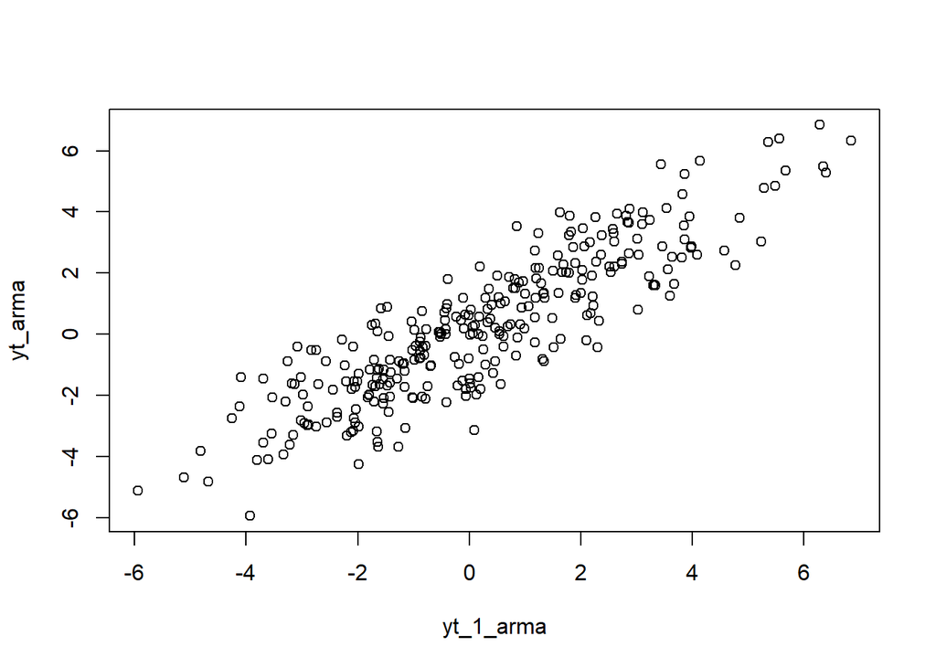

```r
plot(y=yt_arma,x=yt_1_arma)
```

Berdasarkan scatterplot tersebut, terlihat bahwa terdapat hubungan positif antara $Y_t$ dengan $Y_{t-1}$. Hal ini sesuai dengan teori yang ada.

```r
cor(yt_arma,yt_1_arma)
```

```
## [1] 0.8786243
```

Untuk model ARMA(2,2):

$$\gamma_1 = (\theta_1 + \theta_1\theta_2 + \phi_1 +
\phi_1\theta_1)\sigma^2
+ \phi_2
\gamma_0=(0.4+0.4(0.6)+0.5+0.5(0.4))\sigma^2+0.2(1.92\sigma^2)=1.724\sigma^2$$

$$\gamma_2 = \theta_2 \sigma^2 + \phi_1 \gamma_1 + \phi_2
\gamma_0=0.6\sigma^2+0.5(1.724\sigma^2)+0.2(1.92\sigma^2)=1.846\sigma^2$$

$$\gamma_3 = \phi_1 \gamma_2 + \phi_2
\gamma_1=0.5(1.846\sigma^2)+0.2(1.724\sigma^2)=1.2678\sigma^2$$

Sehingga autokorelasi:

$$\rho_1 =
\frac{\gamma_1}{\gamma_0}=\frac{1.724\sigma^2}{1.92\sigma^2}=0.8979$$

### Korelasi antara Yt dengan Yt-2

```r
#Yt
yt_arma2 <- arma22[-c(1,2)]
yt_arma2
```

```
##   [1]  1.829616212  3.338987674  1.597880477  1.343086922 -0.893315311
##   [6] -0.783861667 -2.122426266 -3.214666908 -3.604458242 -4.085991203
##  [11] -1.416574090 -1.587141776  0.836410375 -0.698279074 -1.033891756
##  [16]  0.401878485  0.963779574  1.737426411  2.027534887  1.783057485
##  [21]  3.228028156  1.902817714  2.326184595  0.429177593 -1.265925023
##  [26] -3.690439177 -3.536829619 -3.255881391 -0.883482236 -0.236910677
##  [31]  0.562672469 -1.641086593  0.093760401 -3.128878431 -1.639196015
##  [36] -3.535617598 -2.078776092 -0.408698060  0.854523269  3.537265448
##  [41]  4.130777554  5.672467388  5.356942826  6.283429418  6.844103560
##  [46]  6.340822559  5.480226200  4.849967345  3.807529429  2.512366668
##  [51]  2.220531582  0.939693323  0.869860544 -0.121178134 -1.528616080
##  [56] -2.100911970 -1.795414430 -2.009825226 -1.541132904 -2.282446562
##  [61] -0.189578310 -0.981745589  0.132185605 -1.980457329 -1.289073546
##  [66] -1.449848944 -0.069115858  0.635505577  1.067248341  0.914700393
##  [71]  0.328510940  0.826947125  1.495300373  2.069102183  2.865871882
```

[output cut: 45 more lines]

```r
#Yt-1
yt_1_arma2 <- arma22[-c(299,300)]
yt_1_arma2
```

```
##   [1]  0.521389891  1.202186204  1.829616212  3.338987674  1.597880477
##   [6]  1.343086922 -0.893315311 -0.783861667 -2.122426266 -3.214666908
##  [11] -3.604458242 -4.085991203 -1.416574090 -1.587141776  0.836410375
##  [16] -0.698279074 -1.033891756  0.401878485  0.963779574  1.737426411
##  [21]  2.027534887  1.783057485  3.228028156  1.902817714  2.326184595
##  [26]  0.429177593 -1.265925023 -3.690439177 -3.536829619 -3.255881391
##  [31] -0.883482236 -0.236910677  0.562672469 -1.641086593  0.093760401
##  [36] -3.128878431 -1.639196015 -3.535617598 -2.078776092 -0.408698060
##  [41]  0.854523269  3.537265448  4.130777554  5.672467388  5.356942826
##  [46]  6.283429418  6.844103560  6.340822559  5.480226200  4.849967345
##  [51]  3.807529429  2.512366668  2.220531582  0.939693323  0.869860544
##  [56] -0.121178134 -1.528616080 -2.100911970 -1.795414430 -2.009825226
##  [61] -1.541132904 -2.282446562 -0.189578310 -0.981745589  0.132185605
##  [66] -1.980457329 -1.289073546 -1.449848944 -0.069115858  0.635505577
##  [71]  1.067248341  0.914700393  0.328510940  0.826947125  1.495300373
```

[output cut: 45 more lines]

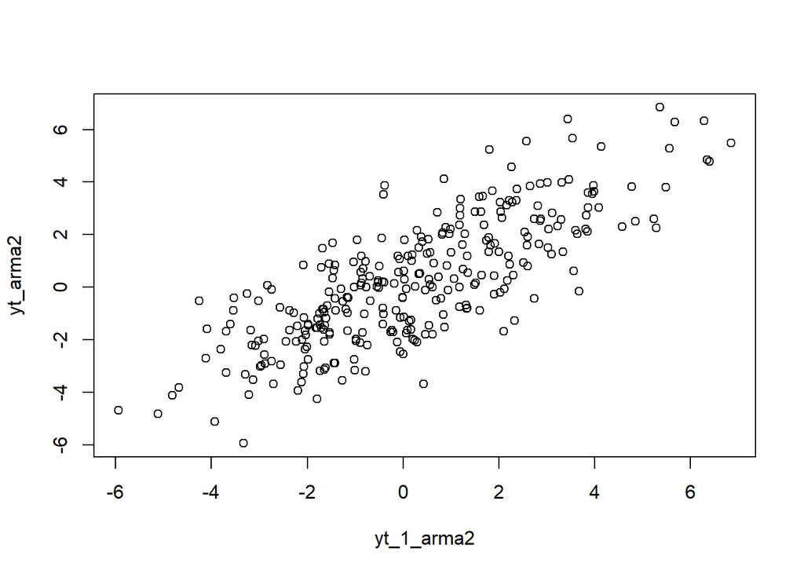

```r
plot(y=yt_arma2,x=yt_1_arma2)
```

```r
cor(yt_arma2,yt_1_arma2)
```

```
## [1] 0.7849278
```

$$\rho_2 = \frac{\gamma_2}{\gamma_0} =
\frac{1.846\sigma^2}{1.92\sigma^2}=0.9614$$

### Korelasi antara Yt dengan Yt-3

```r
#Yt
yt_arma3 <- arma22[-c(1,2,3)]
yt_arma3
```

```
##   [1]  3.338987674  1.597880477  1.343086922 -0.893315311 -0.783861667
##   [6] -2.122426266 -3.214666908 -3.604458242 -4.085991203 -1.416574090
##  [11] -1.587141776  0.836410375 -0.698279074 -1.033891756  0.401878485
##  [16]  0.963779574  1.737426411  2.027534887  1.783057485  3.228028156
##  [21]  1.902817714  2.326184595  0.429177593 -1.265925023 -3.690439177
##  [26] -3.536829619 -3.255881391 -0.883482236 -0.236910677  0.562672469
##  [31] -1.641086593  0.093760401 -3.128878431 -1.639196015 -3.535617598
##  [36] -2.078776092 -0.408698060  0.854523269  3.537265448  4.130777554
##  [41]  5.672467388  5.356942826  6.283429418  6.844103560  6.340822559
##  [46]  5.480226200  4.849967345  3.807529429  2.512366668  2.220531582
##  [51]  0.939693323  0.869860544 -0.121178134 -1.528616080 -2.100911970
##  [56] -1.795414430 -2.009825226 -1.541132904 -2.282446562 -0.189578310
##  [61] -0.981745589  0.132185605 -1.980457329 -1.289073546 -1.449848944
##  [66] -0.069115858  0.635505577  1.067248341  0.914700393  0.328510940
##  [71]  0.826947125  1.495300373  2.069102183  2.865871882  2.644985002
```

[output cut: 45 more lines]

```r
#Yt-1
yt_1_arma3 <- arma22[-c(298,299,300)]
yt_1_arma3
```

```
##   [1]  0.521389891  1.202186204  1.829616212  3.338987674  1.597880477
##   [6]  1.343086922 -0.893315311 -0.783861667 -2.122426266 -3.214666908
##  [11] -3.604458242 -4.085991203 -1.416574090 -1.587141776  0.836410375
##  [16] -0.698279074 -1.033891756  0.401878485  0.963779574  1.737426411
##  [21]  2.027534887  1.783057485  3.228028156  1.902817714  2.326184595
##  [26]  0.429177593 -1.265925023 -3.690439177 -3.536829619 -3.255881391
##  [31] -0.883482236 -0.236910677  0.562672469 -1.641086593  0.093760401
##  [36] -3.128878431 -1.639196015 -3.535617598 -2.078776092 -0.408698060
##  [41]  0.854523269  3.537265448  4.130777554  5.672467388  5.356942826
##  [46]  6.283429418  6.844103560  6.340822559  5.480226200  4.849967345
##  [51]  3.807529429  2.512366668  2.220531582  0.939693323  0.869860544
##  [56] -0.121178134 -1.528616080 -2.100911970 -1.795414430 -2.009825226
##  [61] -1.541132904 -2.282446562 -0.189578310 -0.981745589  0.132185605
##  [66] -1.980457329 -1.289073546 -1.449848944 -0.069115858  0.635505577
##  [71]  1.067248341  0.914700393  0.328510940  0.826947125  1.495300373
```

[output cut: 45 more lines]

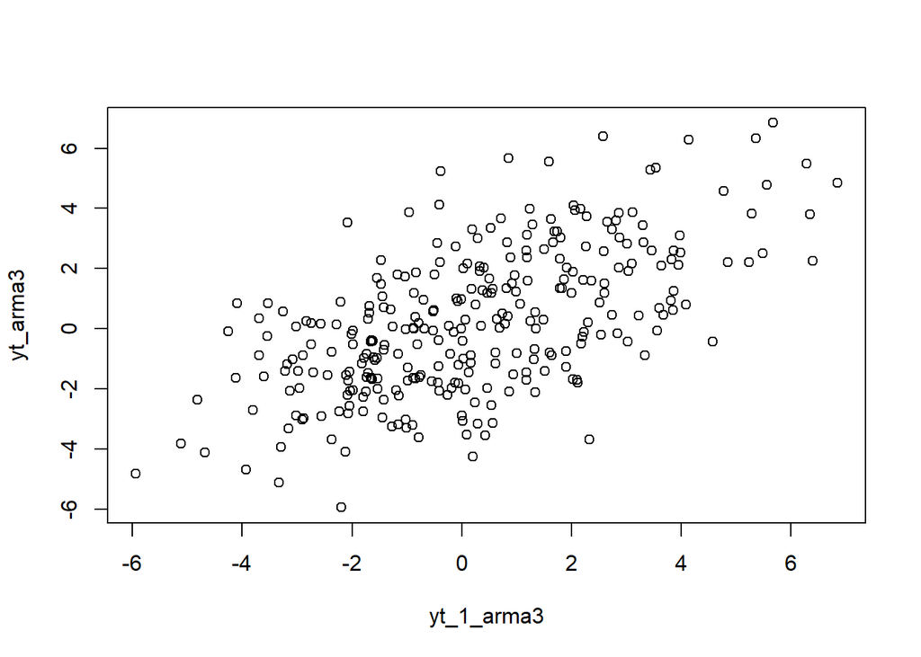

```r
plot(y=yt_arma3,x=yt_1_arma3)
```

```r
cor(yt_arma3,yt_1_arma3)
```

```
## [1] 0.6069956
```

$$\rho_3 =
\frac{\gamma_3}{\gamma_0}=\frac{1.2678\sigma^2}{1.92\sigma^2}=0,66$$